# Text visualization

MACS 40700 University of Chicago

## Basic workflow for text analysis

- Obtain your text sources
- Extract documents and move into a corpus
- Transformation
- Extract features
- Perform analysis

## Obtain your text sources

- Web sites
  - Twitter
- Databases
- PDF documents
- Digital scans of printed materials

## Extract documents and move into a corpus

- Corpus
- Character string

## Transformation

- Tagging segments of speech for part-of-speech (nouns, verbs, adjectives, etc.) or entity recognition (person, place, company, etc.)
- Standard text processing
  - Converting to lower case
  - Removing punctuation
  - Removing numbers
  - Removing stopwords
  - Removing domain-specific stopwords
  - Stemming

## Extract features

- Quantify your measures
- Bag-of-words model
- Term-document matrix
  - Each row is a document
  - Each column is a term
  - Each cell represents the frequency of the term appearing in the document
- Missing context

## Perform analysis

- Word frequency
- Collocation
- Dictionary tagging
- Document classification
- Corpora comparison
- Topic modeling

## Wordclouds

```r
library(wordcloud)

# get tweets
rt <- search_tweets(
  q = "#rstats",
  n = 3000,
  include_rts = FALSE
)
rt
```

```
## # A tibble: 2,705 x 42
##    status_id  created_at          user_id  screen_name text         source
##    <chr>      <dttm>              <chr>    <chr>       <chr>        <chr>
##  1 998960493… 2018-05-22 16:15:16 1445929… Rbloggers   July 5th &a… r-blo…
##  2 998959904… 2018-05-22 16:12:55 3967465… grssnbchr   Willst Du w… Tweet…
##  3 998959845… 2018-05-22 16:12:41 89191817 BigDataIns… "Big | Data… Paper…
##  4 998959486… 2018-05-22 16:11:16 21136238 rihender    Will exchan… Twitt…
##  5 998959214… 2018-05-22 16:10:11 3044686… thinkR_fr   #RStats — C… Hoots…
##  6 998957195… 2018-05-22 16:02:09 2335858… CRANberrie… CRAN update… CRANb…
##  7 998956655… 2018-05-22 16:00:01 2953443… RLangTip    List of R p… Tweet…
##  8 998955208… 2018-05-22 15:54:15 2859870… tripartio   Why multico… Twitt…
##  9 998955141… 2018-05-22 15:54:00 3909197… theothered… Mañana! Aco… Twitt…
## 10 998954783… 2018-05-22 15:52:34 8974458… lobrowR     "I have bee… Twitt…
## # ... with 2,695 more rows, and 36 more variables:
## #   reply_to_status_id <chr>, reply_to_user_id <chr>,
## #   reply_to_screen_name <chr>, is_quote <lgl>, is_retweet <lgl>,
## #   favorite_count <int>, retweet_count <int>, hashtags <list>,
## #   symbols <list>, urls_url <list>, urls_t.co <list>,
## #   urls_expanded_url <list>, media_url <list>, media_t.co <list>,
## #   media_expanded_url <list>, media_type <list>, ext_media_url <list>,
## #   ext_media_t.co <list>, ext_media_expanded_url <list>,
## #   ext_media_type <lgl>, mentions_user_id <list>,
## #   mentions_screen_name <list>, lang <chr>, quoted_status_id <chr>,
## #   quoted_text <chr>, retweet_status_id <chr>, retweet_text <chr>,
## #   place_url <chr>, place_name <chr>, place_full_name <chr>,
## #   place_type <chr>, country <chr>, country_code <chr>,
## #   geo_coords <list>, coords_coords <list>, bbox_coords <list>
```

```r
# tokenize
rstats_token <- rt %>%
  unnest_tokens(word, text, token = "tweets") %>%
  filter(!word %in% stop_words$word)
glimpse(rstats_token)
```

```
## Observations: 32,145
## Variables: 42
## $ status_id              <chr> "998960493384658945", "9989604933846589...
## $ created_at             <dttm> 2018-05-22 16:15:16, 2018-05-22 16:15:...
## $ user_id                <chr> "144592995", "144592995", "144592995", ...
## $ screen_name            <chr> "Rbloggers", "Rbloggers", "Rbloggers", ...
## $ source                 <chr> "r-bloggers.com", "r-bloggers.com", "r-...
## $ reply_to_status_id     <chr> NA, NA, NA, NA, NA, NA, NA, NA, NA, NA,...
## $ reply_to_user_id       <chr> NA, NA, NA, NA, NA, NA, NA, NA, NA, NA,...
## $ reply_to_screen_name   <chr> NA, NA, NA, NA, NA, NA, NA, NA, NA, NA,...
## $ is_quote               <lgl> FALSE, FALSE, FALSE, FALSE, FALSE, FALS...
## $ is_retweet             <lgl> FALSE, FALSE, FALSE, FALSE, FALSE, FALS...
## $ favorite_count         <int> 1, 1, 1, 1, 1, 1, 1, 1, 1, 1, 1, 1, 1, ...
## $ retweet_count          <int> 0, 0, 0, 0, 0, 0, 0, 0, 0, 0, 0, 0, 0, ...
## $ hashtags               <list> [<"rstats", "DataScience">, <"rstats",...
```

[output cut: 29 more lines]

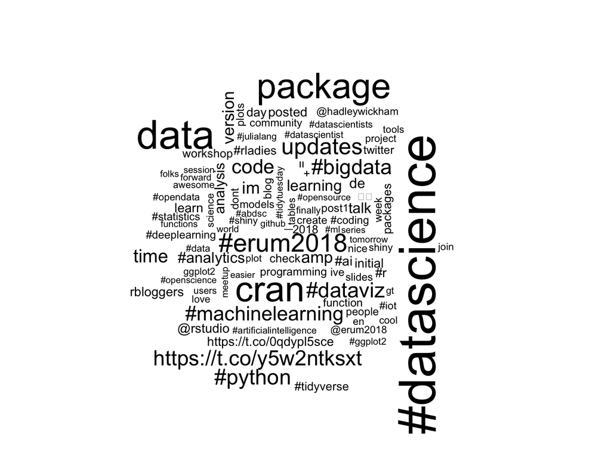

```r
# plot
rstats_token %>%
  count(word) %>%
  filter(word != "#rstats") %>%
  with(wordcloud(word, n, max.words = 100))
```

## Wordclouds

```r
# get tweets
pope <- get_timelines("Pontifex",
                      n = 3200,
                      include_rts = FALSE)

# tokenize
pope_token <- pope %>%
  unnest_tokens(word, text, token = "tweets") %>%
  filter(!word %in% stop_words$word)
glimpse(pope_token)
```

```
## Observations: 11,379
## Variables: 42
## $ status_id              <chr> "998888705803935744", "9988887058039357...
## $ created_at             <dttm> 2018-05-22 11:30:00, 2018-05-22 11:30:...
## $ user_id                <chr> "500704345", "500704345", "500704345", ...
## $ screen_name            <chr> "Pontifex", "Pontifex", "Pontifex", "Po...
## $ source                 <chr> "TweetDeck", "TweetDeck", "TweetDeck", ...
## $ reply_to_status_id     <lgl> NA, NA, NA, NA, NA, NA, NA, NA, NA, NA,...
## $ reply_to_user_id       <lgl> NA, NA, NA, NA, NA, NA, NA, NA, NA, NA,...
## $ reply_to_screen_name   <lgl> NA, NA, NA, NA, NA, NA, NA, NA, NA, NA,...
## $ is_quote               <lgl> FALSE, FALSE, FALSE, FALSE, FALSE, FALS...
## $ is_retweet             <lgl> FALSE, FALSE, FALSE, FALSE, FALSE, FALS...
## $ favorite_count         <int> 22951, 22951, 22951, 22951, 22951, 4787...
## $ retweet_count          <int> 4820, 4820, 4820, 4820, 4820, 10841, 10...
## $ hashtags               <list> [NA, NA, NA, NA, NA, NA, NA, NA, NA, N...
```

[output cut: 29 more lines]

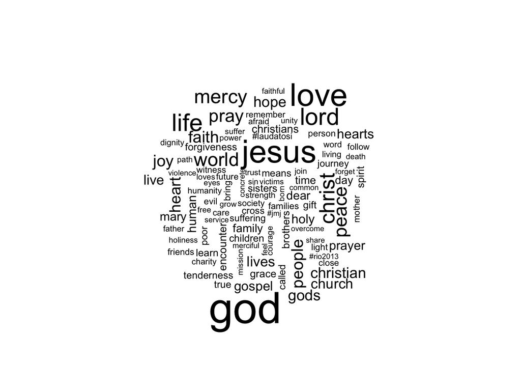

```r
# plot
pope_token %>%
  count(word) %>%
  with(wordcloud(word, n, max.words = 100))
```

## Comparison cloud

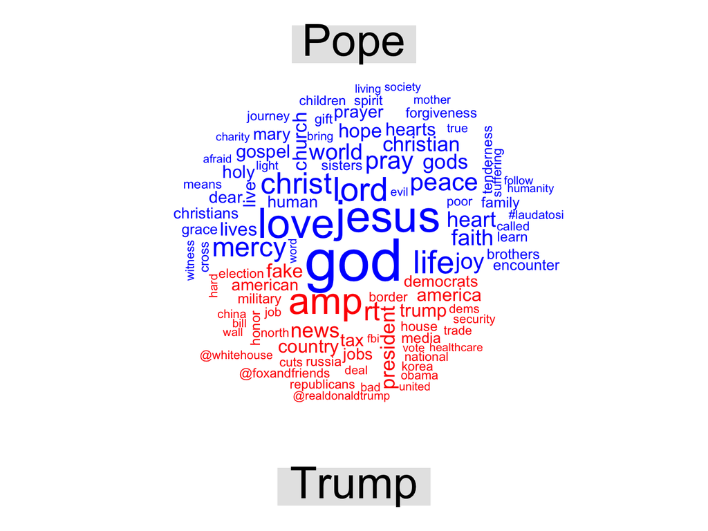

```r
library(reshape2)

# get fresh trump tweets
trump <- get_timelines("realdonaldtrump",
                      n = 3200,
                      include_rts = FALSE)

# tokenize
trump_token <- trump %>%
  unnest_tokens(word, text, token = "tweets") %>%
  filter(!word %in% stop_words$word)

bind_rows(Trump = trump_token, Pope = pope_token, .id = "person") %>%
  count(word, person) %>%
  acast(word ~ person, value.var = "n", fill = 0) %>%
  comparison.cloud(max.words = 100, colors = c("blue", "red"))
```

## N-gram viewers

- N-gram
- [Google Books Ngram Viewer](https://books.google.com/ngrams)
  - [Calendar of Meaningful Dates](https://www.xkcd.com/1140/)
- [How The Internet* Talks](https://projects.fivethirtyeight.com/reddit-ngram/?keyword=triggered.safe_space.sjw.snowflake&start=20071015&end=20161231&smoothing=10)

## Geospatial visualization

- [Which Curse Words Are Popular In Your State? Find Out From These Maps.](http://www.huffingtonpost.com/entry/which-curse-words-are-popular-in-your-state_us_55a80662e4b04740a3df54b8)
- [Hate Map](http://users.humboldt.edu/mstephens/hate/hate_map.html)
- [Soda vs. Pop with Twitter](http://blog.echen.me/2012/07/06/soda-vs-pop-with-twitter/)

## Network analysis with text

- Use text features to identify edges between nodes in a network
- [How every #GameOfThrones episode has been discussed on Twitter](https://interactive.twitter.com/game-of-thrones/#?episode=1)

## Sentiment analysis

> I am happy

## Dictionaries

```r
get_sentiments("bing")
```

```
## # A tibble: 6,788 x 2
##    word        sentiment
##    <chr>       <chr>
##  1 2-faced     negative
##  2 2-faces     negative
##  3 a+          positive
##  4 abnormal    negative
##  5 abolish     negative
##  6 abominable  negative
##  7 abominably  negative
##  8 abominate   negative
##  9 abomination negative
## 10 abort       negative
## # ... with 6,778 more rows
```

## Dictionaries

```r
get_sentiments("afinn")
```

```
## # A tibble: 2,476 x 2
##    word       score
##    <chr>      <int>
##  1 abandon       -2
##  2 abandoned     -2
##  3 abandons      -2
##  4 abducted      -2
##  5 abduction     -2
##  6 abductions    -2
##  7 abhor         -3
##  8 abhorred      -3
##  9 abhorrent     -3
## 10 abhors        -3
## # ... with 2,466 more rows
```

## Dictionaries

```r
get_sentiments("nrc")
```

```
## # A tibble: 13,901 x 2
##    word        sentiment
##    <chr>       <chr>
##  1 abacus      trust
##  2 abandon     fear
##  3 abandon     negative
##  4 abandon     sadness
##  5 abandoned   anger
##  6 abandoned   fear
##  7 abandoned   negative
##  8 abandoned   sadness
##  9 abandonment anger
## 10 abandonment fear
## # ... with 13,891 more rows
```

## Dictionaries

```r
get_sentiments("nrc") %>%
  count(sentiment)
```

```
## # A tibble: 10 x 2
##    sentiment        n
##    <chr>        <int>
##  1 anger         1247
##  2 anticipation   839
##  3 disgust       1058
##  4 fear          1476
##  5 joy            689
##  6 negative      3324
##  7 positive      2312
##  8 sadness       1191
##  9 surprise       534
## 10 trust         1231
```

## Measuring overall sentiment

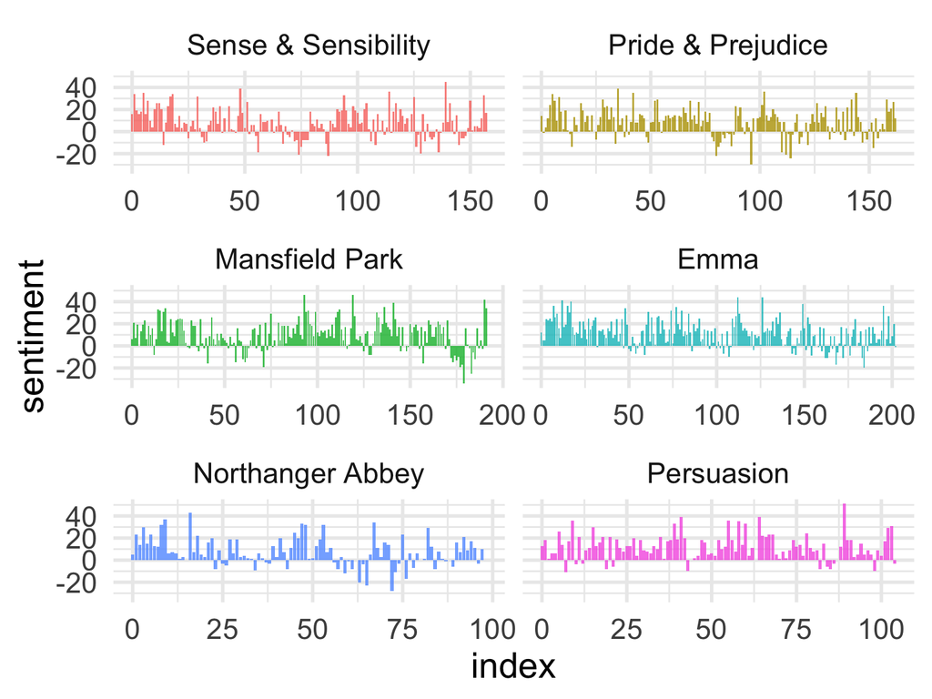

```r
library(janeaustenr)

tidy_books <- austen_books() %>%
  group_by(book) %>%
  mutate(linenumber = row_number(),
         chapter = cumsum(str_detect(text,
                                     regex("^chapter [\\divxlc]",
                                           ignore_case = TRUE)))) %>%
  ungroup() %>%
  unnest_tokens(word, text)

janeaustensentiment <- tidy_books %>%
  inner_join(get_sentiments("bing")) %>%
  count(book, index = linenumber %/% 80, sentiment) %>%
  spread(sentiment, n, fill = 0) %>%
  mutate(sentiment = positive - negative)

ggplot(janeaustensentiment, aes(index, sentiment, fill = book)) +
        geom_bar(alpha = 0.8, stat = "identity", show.legend = FALSE) +
        facet_wrap(~book, ncol = 2, scales = "free_x")
```

## Exploring content of Donald Trump’s Twitter timeline

- [Text analysis of Trump’s tweets confirms he writes only the (angrier) Android half](http://varianceexplained.org/r/trump-tweets/)
- [Trump’s Android and iPhone tweets, one year later](http://varianceexplained.org/r/trump-followup/)